# 7.10汇报

2026-07-10

# **项目题目 EAT-Lancet 膳食模式与心力衰竭的关联性研究**

## 1.研究背景

### 1.1心力衰竭（heart failure, HF）

多种心脏功能病理生理障碍的终末表现，全球有超过2600万人被诊断出患有心力衰竭（HF），其中美国就有超过600万人。随着生存率提升和人口老龄化，心力衰竭的患病率持续上升，预计2030年所有性别和种族老年人的心力衰竭发病率将大幅上升。良好健康的饮食模式是减轻心力衰竭患病率和负担的重要策略。

### 1.2 EAT-Lancet diet（ELD）

2019年EAT-Lancet委员会提出了一种全球适用的饮食模式——“星球健康膳食”（Planetary Health Diet, PHD），又称EAT-Lancet饮食（EAT-Lancet diet，ELD）模式，它强调全谷物、豆类和蔬菜等植物性食物，适量食用鱼类，并限制乳制品和肉类的摄入。EAT-Lancet饮食旨在促进全球饮食转型，促进人类健康，同时保护环境。

近年证据表明，高依从性的EDL可降低心血管疾病死亡率、冠心病及糖尿病风险，但目前ELD与HF的关联性研究不足

## 2.研究问题

1. 总人群分析：在美国成年人群中，EAT-Lancet饮食依从性（ELD评分）与心力衰竭患病是否存在关联？
2. 亚组分析：上述关联在不同性别、年龄、肥胖状态、吸烟、饮酒、体力活动、高血压、糖尿病、血脂状况人群中是否存在异质性？

## 3.数据来源与研究对象

数据来源：美国国家健康与营养调查（NHANES）（2015-2016、2017-2018两个周期）。 研究对象：NHANES数据库中年龄20岁及其以上人群

## 4.变量说明

### 4.1暴露变量：ELD评分（连续变量，范围0–42分）

基于EAT-Lancet推荐的14类食物组摄入量，按既定评分算法计算。根据个体食物摄入量的多少，每种食物的评分范围为0至3分，总评分范围为0至42分。强调摄入食物组给予正向赋分，摄入量越多得分越高，而限制摄入 食物组给予负向评分，摄入量越少得分越高。

### 4.2结局变量

心力衰竭患病（二分类变量）。

### 4.3 协变量

①人口学变量：年龄、性别、种族、教育水平；

②生活方式：吸烟、饮酒、体力活动；

③人体测量与疾病史：BMI、高血压、糖尿病、血脂状况；

④其他：总能量摄入（kcal/d）。

## 5.数据清洗

（1）纳入：年龄 ≥ 20岁；

（2）排除：①未完成24小时膳食回顾，缺失ELD评分所需食物组数据； ②心力衰竭患病信息缺失； ③基线资料缺失者，如年龄、性别、种族、教育水平、吸烟、饮酒等； ④日均能量摄入异常（(men: <800 or >4200 kcal/days; women: <600 or >3500 kcal/days）。

[figure not shown]

图1 研究数据清洗流程

## 6.描述性统计

[output not shown]

## 7.数据可视化

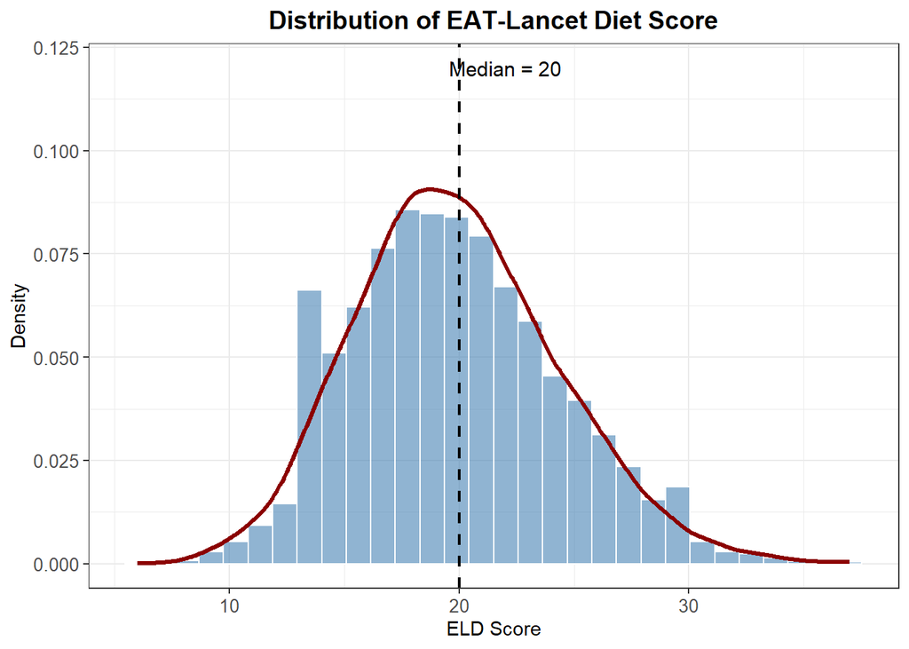

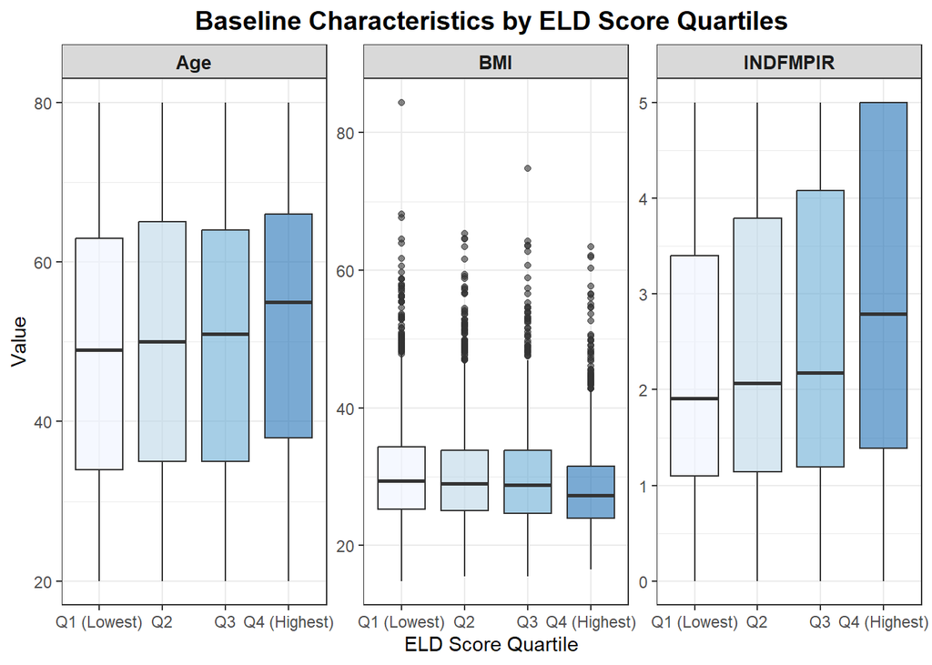

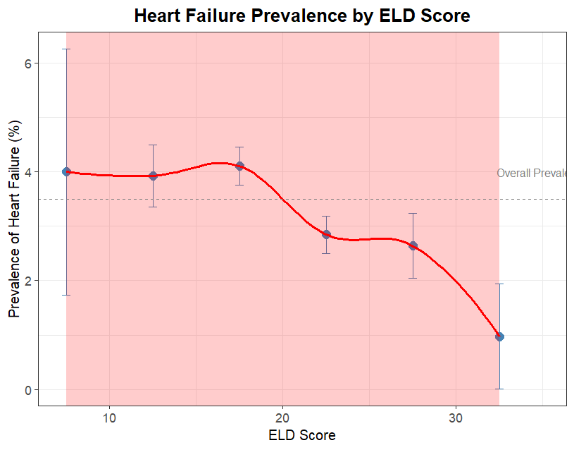

心衰患病率与ELD评分关系图

## 8.统计分析或模型结果

### 8.1加权logistic回归

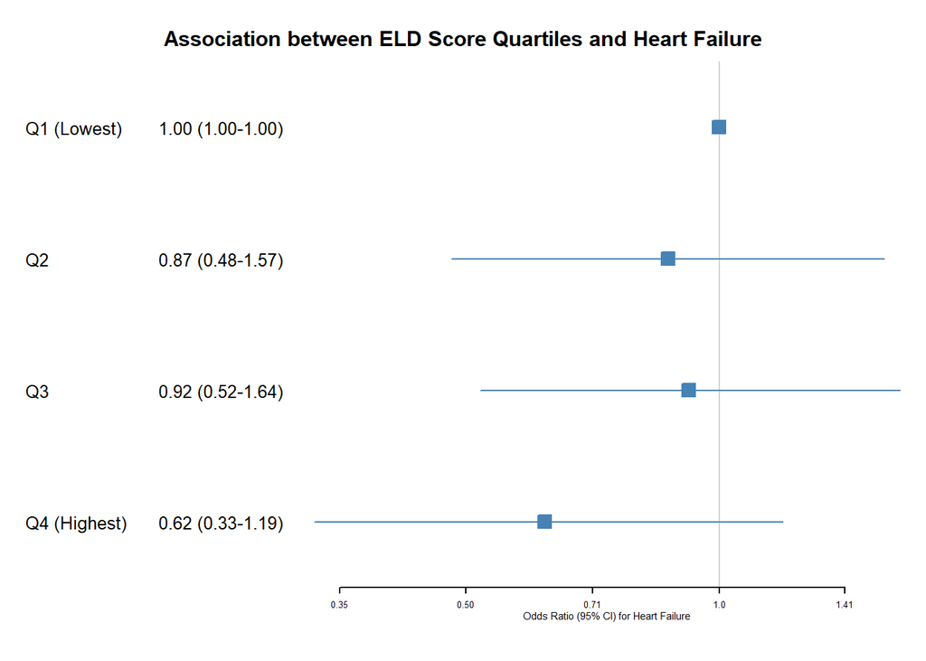

| 变量 | 模型 1 OR (95%CI) | 模型 1 P值 | 模型 2 OR (95%CI) | 模型 2 P值 | 模型 3 OR (95%CI) | 模型 3 P值 |
| --- | --- | --- | --- | --- | --- | --- |
| ELD score | 0.94 (0.90～0.99) | 0.012 | 0.94 (0.89～0.98) | 0.012 | 0.96 (0.90～1.01) | 0.089 |
| ELD score分层 |  |  |  |  |  |  |
| Quartile 1 | — |  | — |  | — |  |
| Quartile 2 | 0.91 (0.55～1.52) | 0.721 | 0.88 (0.52～1.48) | 0.607 | 0.87 (0.48～1.57) | 0.602 |
| Quartile 3 | 0.84 (0.51～1.40) | 0.491 | 0.87 (0.52～1.45) | 0.574 | 0.92 (0.52～1.64) | 0.760 |
| Quartile 4 | 0.52 (0.30～0.90) | 0.022 | 0.51 (0.28～0.90) | 0.024 | 0.62 (0.33～1.19) | 0.136 |
| 趋势效应 |  | **0.025** |  | **0.025** |  | **0.167** |

*注：“—” 为无数据；模型1：未调整协变量；模型2：调整年龄、性别、种族、教育水平；模型3：调整年龄、性别、种族、教育水平、吸烟、饮酒、体力活动、BMI、高血压、糖尿病、血脂异常、总能量摄入。*

1.ELD连续得分

模型1：OR=0.94，P=0.012，ELD 得分每升高1分，结局患病风险降低6%，差异有统计学意义；模型2（调整人口社会学变量）：OR=0.94，P=0.012，ELD 得分每升高1分，结局患病风险降低6%，差异有统计学意义；模型3：OR=0.96，P=0.089，进一步纳入生活方式、慢性病等混杂因素后，EAT-Lancet饮食与心衰的关联不具有统计学显著性。

2.ELD四分位数分层分析

3个模型中Q2、Q3的P＞0.05，最低依从组心衰风险无统计学差异，Q4（最高依从组）的模型1（P=0.022）、模型2（P=0.024）与最低依从组心衰风险有统计学差异，模型3（P=0.136）无统计学意义； 趋势检验：模型 1、模型 2 趋势 P 均 =0.025，即随着ELD依从性逐级升高，结局风险呈显著线性下降趋势。模型3趋势P=0.167，即在校正生活方式、慢性病、BMI等变量后，剂量-反应趋势没有统计学差异。

### 8.2分层logistic分析

| Group | Subgroup | N | Events | Continuous OR (95% CI) | P value | Q2 OR (95% CI) | Q3 OR (95% CI) | Q4 OR (95% CI) | P for trend | P for interaction |
| --- | --- | --- | --- | --- | --- | --- | --- | --- | --- | --- |
| Age | <60 | 4906 | 53 | 0.98 (0.90-1.08) | 0.724 | 0.69 (0.28-1.73) | 0.86 (0.29-2.50) | 0.86 (0.25-2.97) | 0.752 | 0.7963 |
|  | ≥60 | 2693 | 213 | 0.95 (0.89-1.01) | 0.084 | 0.88 (0.47-1.65) | 0.94 (0.50-1.77) | 0.60 (0.26-1.36) | 0.222 | 0.7963 |
| Sex | Male | 3658 | 157 | 0.92 (0.86-1.00) | 0.045 | 0.77 (0.39-1.50) | 0.68 (0.30-1.56) | 0.38 (0.15-0.97) | 0.069 | 0.1147 |
|  | Female | 3941 | 109 | 1.00 (0.94-1.07) | 0.941 | 1.11 (0.44-2.81) | 1.42 (0.56-3.66) | 1.10 (0.46-2.66) | 0.537 | 0.1147 |
| BMI | <30 | 4385 | 101 | 0.96 (0.89-1.03) | 0.190 | 1.07 (0.46-2.47) | 0.72 (0.36-1.47) | 0.74 (0.28-1.94) | 0.362 | 0.8643 |
|  | ≥30 | 3214 | 165 | 0.96 (0.89-1.04) | 0.271 | 0.85 (0.43-1.69) | 1.03 (0.47-2.24) | 0.58 (0.21-1.60) | 0.380 | 0.8643 |
| Smoking | Non-smoker | 4340 | 95 | 0.99 (0.91-1.07) | 0.721 | 0.95 (0.37-2.43) | 1.45 (0.64-3.30) | 0.89 (0.37-2.14) | 0.720 | 0.2724 |
|  | Current smoker | 3259 | 171 | 0.94 (0.89-1.00) | 0.058 | 0.86 (0.43-1.75) | 0.69 (0.35-1.37) | 0.56 (0.26-1.21) | 0.095 | 0.2724 |
| Alcohol | Non-drinker | 1544 | 48 | 0.93 (0.80-1.10) | 0.375 | 0.36 (0.08-1.57) | 0.76 (0.24-2.39) | 0.85 (0.25-2.89) | 0.791 | 0.9031 |
|  | Drinker | 6055 | 218 | 0.96 (0.91-1.01) | 0.109 | 0.99 (0.54-1.83) | 0.97 (0.53-1.79) | 0.60 (0.29-1.24) | 0.190 | 0.9031 |
| Physical Activity | Inactive | 3909 | 193 | 0.93 (0.88-0.99) | 0.036 | 0.73 (0.40-1.34) | 0.56 (0.29-1.05) | 0.54 (0.28-1.05) | 0.026 | 0.0810 |
|  | Active | 3690 | 73 | 1.01 (0.92-1.09) | 0.881 | 1.80 (0.60-5.43) | 2.99 (0.92-9.69) | 1.35 (0.34-5.33) | 0.351 | 0.0810 |
| Hypertension | No | 4755 | 45 | 0.98 (0.92-1.05) | 0.541 | 1.41 (0.41-4.90) | 0.85 (0.23-3.22) | 0.77 (0.22-2.70) | 0.500 | 0.9120 |
|  | Yes | 2844 | 221 | 0.95 (0.90-1.01) | 0.090 | 0.76 (0.41-1.41) | 0.94 (0.48-1.87) | 0.59 (0.29-1.22) | 0.205 | 0.9120 |
| Diabetes | No | 6419 | 146 | 0.97 (0.92-1.02) | 0.192 | 1.02 (0.53-1.96) | 0.77 (0.39-1.51) | 0.78 (0.37-1.62) | 0.279 | 0.9658 |
|  | Yes | 1180 | 120 | 0.95 (0.85-1.05) | 0.281 | 0.80 (0.32-2.02) | 1.34 (0.53-3.39) | 0.45 (0.12-1.72) | 0.526 | 0.9658 |
| Dyslipidemia | No | 6751 | 246 | 0.94 (0.89-1.00) | 0.056 | 0.94 (0.53-1.68) | 0.83 (0.48-1.44) | 0.56 (0.27-1.16) | 0.090 | 0.2047 |
|  | Yes | 848 | 20 | 1.06 (0.93-1.20) | 0.357 | 0.22 (0.02-1.98) | 1.73 (0.23-12.92) | 1.39 (0.24-8.07) | 0.280 | 0.2047 |

```
## `height` was translated to `width`.
```

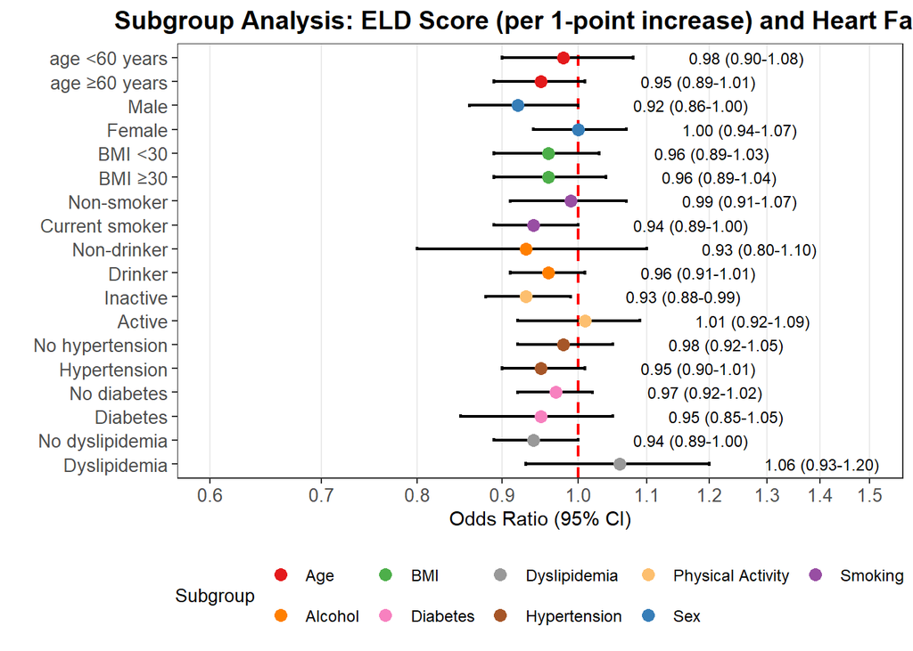

## 9.结果解释

### 9.1 总人群多变量Logistic回归分析：

①连续ELD评分：

模型 1（未校正任何协变量）：心衰患病OR=0.94，P=0.012。提示依从EAT-Lancet饮食程度越高，心衰患病风险显著降低；

模型 2（校正年龄、性别、种族、教育）：OR=0.94，P=0.012，EAT-Lancet饮食对仍有保护作用；

模型 3（完全校正人口学+生活方式+代谢慢病+总能量摄入）：OR=0.96，P=0.089，关联无统计学意义。

②ELD 评分四分位数分析：

3个模型中Q2、Q3的P＞0.05，最低依从组心衰风险无统计学差异，Q4（最高依从组）的模型1（P=0.022）、模型2（P=0.024）与最低依从组心衰风险有统计学差异，模型3（P=0.136）无统计学意义；

趋势检验中模型 1、2存在显著剂量反应关系（P=0.025）；完全校正模型3趋势效应无统计学意义。

结论：未校正 / 仅校正人口学特征时，更高EAT-Lancet饮食依从性显著降低美国成人心衰患病风险，且存在剂量反应关系；但在校正肥胖、慢病、生活方式等全混杂因素后，该独立关联不再具有统计学显著性，提示饮食对心衰的保护作用很大程度通过代谢、生活方式中介实现。

### 9.2 分层Logistic回归分析：

协变量调整了”Age”, “Sex”, “Race”, “Education”, “Smoking”, “Alcohol”, “PhysicalActivity”, “BMI”, “Hypertension”, “Diabetes”,“Dyslipidemia”,“Energy”。

所有分层的交互检验P＞0.05，提示ELD评分与心衰的关联在各亚组间不存在显著的统计学效应、无明显人群异质性。仅在男性、吸烟人群、无体力活动人群中观察到EAT-Lancet饮食降低心衰风险的保护趋势，其中缺乏体力活动者的剂量反应趋势最为明显，提示运动不足人群可能更能从 EAT-Lancet 膳食模式获益。

## 10.局限性

（1）研究设计固有缺陷： 本研究为NHANES横断面研究，仅能解释关联性，无法推断因果，无法确定是低ELD依从在先诱发心衰，还是患者在心衰患病后改变饮食行为，其次没有长期随访不能反映膳食模式长期暴露对心衰发病的累积影响。

（2）存在测量偏倚： 膳食数据为24小时膳食回顾自我报告，存在回忆偏倚、报告偏倚，NHANES食物数据库无法精准匹配EAT-Lancet 全部膳食组分，评分构建存在一定测量误差； 心力衰竭依靠自我报告，无客观临床诊断指标，可能存在漏报、错报现象。

（3）尽管校正多类协变量，仍存在其他的潜在混杂因素。

（4）亚组分析统计效能不足： 分层后各组样本量、病例数大幅减少，统计检验效能下降，易出现假阴性。

（5）研究仅纳入美国成年人群，人群种族、饮食文化、医疗体系与国内人群差异极大，结论无法直接外推至中国人群。

## 11.个人总结

本研究基于 NHANES 横断面数据，采用加权多因素Logistic回归、四分位数趋势检验及分层交互分析，系统探究了美国20岁及以上人群EAT-Lancet膳食依从性与心力衰竭患病的关联。 结果显示，未校正混杂时高ELD评分与更低心衰患病风险显著相关，校正协变量后独立关联消失；分层交互分析未检出显著人群异质性，无体力活动人群可见膳食的保护趋势。

通过本次完整的流行病学横断面统计分析，我系统巩固了大型公共数据库NHANES的数据处理流程，从数据清洗开始逐步分析数据，熟练掌握R语言构建Logistic回归、趋势检验、分层与交互作用分析等核心统计方法，能够逐步校正混杂、分层探索效应，能够规范解读Logistic回归各项效应值的统计学意义；但是受横断面设计、膳食自我报告、病例样本量限制，研究结果仅能探讨两者之间的关联性，无法证实两者间的因果关系，后续研究可以采用前瞻性队列进一步验证，进一步开展中介效应分析，同时扩大样本量，研究不同人群中 EAT-Lancet 膳食模式对心衰的保护作用。